# TreeClassification-HighRes

Aitor Apaolaza

09/01/2016

*Copyright (c) 2015 The University of Manchester, UK.*

*Licenced under LGPL version 2.1. See LICENCE for details.*

*The IDInteraction Attention Classification was developed in the IDInteraction project, funded by the Engineering and Physical Sciences Research Council, UK through grant agreement number EP/M017133/1.*

*Author: Aitor Apaolaza*

## Initialisation and loading data

```
## [1] "All listed packages are already installed"
```

# Setup for the classification algorithm.

**Folder**: /home/aitor/Dropbox/UoM/IDInteractionCode/Rnotebooks

**Experiment**: dual_screen_free_experiment

**Source Videos**: high_quality

**Tracking system**: front_eyes_only

**Using the following list of participants**: P01, P03, P04, P05, P06, P08, P09, P12.

Data for these participants will be read from the CSV files contained in the following folders:

/home/aitor/Dropbox/UoM/IDInteractionCode/Rnotebooks/resources/dual_screen_free_experiment/high_quality/attention/

/home/aitor/Dropbox/UoM/IDInteractionCode/Rnotebooks/resources/dual_screen_free_experiment/high_quality/front_eyes_only/

Loading data

[output not shown]

[output cut: 25 more lines]

From a total of 363562 rows, 2/3 of them (243354) will be used for training, and 1/3 for testing (120208).

## Training the tree classifier

Using the **rpart** library for the following formula:

**attentionName ~ boxHeight + boxRotation + boxArea + boxWidth + widthHeightRatio + boxYcoordRel**

Resulting model:

```
## n= 243354
##
## node), split, n, loss, yval, (yprob)
##       * denotes terminal node
##
##   1) root 243354 78339 tv (0.32191376 0.67808624)
##     2) boxYcoordRel>=0.5477784 46660 14689 ipad (0.68519074 0.31480926)
##       4) widthHeightRatio>=0.3513533 20464  2660 ipad (0.87001564 0.12998436)
##         8) boxHeight< 16.00745 16629   235 ipad (0.98586806 0.01413194) *
##         9) boxHeight>=16.00745 3835  1410 tv (0.36766623 0.63233377) *
##       5) widthHeightRatio< 0.3513533 26196 12029 ipad (0.54080776 0.45919224)
##        10) widthHeightRatio< 0.3123829 3953   249 ipad (0.93700987 0.06299013) *
##        11) widthHeightRatio>=0.3123829 22243 10463 tv (0.47039518 0.52960482)
##          22) boxHeight>=40.9099 4474  1119 ipad (0.74988824 0.25011176) *
##          23) boxHeight< 40.9099 17769  7108 tv (0.40002251 0.59997749)
##            46) boxYcoordRel>=0.6165314 6309  2665 ipad (0.57758757 0.42241243)
##              92) boxYcoordRel< 0.7102898 5348  1760 ipad (0.67090501 0.32909499) *
##              93) boxYcoordRel>=0.7102898 961    56 tv (0.05827263 0.94172737) *
##            47) boxYcoordRel< 0.6165314 11460  3464 tv (0.30226876 0.69773124) *
##     3) boxYcoordRel< 0.5477784 196694 46368 tv (0.23573673 0.76426327)
##       6) boxWidth< 35.16975 48438 20840 tv (0.43024072 0.56975928)
##        12) boxYcoordRel>=0.4132563 3576   296 ipad (0.91722595 0.08277405) *
##        13) boxYcoordRel< 0.4132563 44862 17560 tv (0.39142258 0.60857742)
##          26) boxHeight< 19.00845 34032 16243 tv (0.47728608 0.52271392)
##            52) boxYcoordRel>=0.114887 27792 12066 ipad (0.56584629 0.43415371)
##             104) boxRotation>=-1.25045 8462  1778 ipad (0.78988419 0.21011581) *
##             105) boxRotation< -1.25045 19330  9042 tv (0.46777031 0.53222969)
##               210) boxYcoordRel>=0.2696083 7462  2506 ipad (0.66416510 0.33583490) *
##               211) boxYcoordRel< 0.2696083 11868  4086 tv (0.34428716 0.65571284)
##                 422) boxHeight< 12.36005 1973   331 ipad (0.83223517 0.16776483) *
##                 423) boxHeight>=12.36005 9895  2444 tv (0.24699343 0.75300657) *
##            53) boxYcoordRel< 0.114887 6240   517 tv (0.08285256 0.91714744) *
##          27) boxHeight>=19.00845 10830  1317 tv (0.12160665 0.87839335) *
##       7) boxWidth>=35.16975 148256 25528 tv (0.17218865 0.82781135)
##        14) boxHeight< 13.15735 24821  9766 tv (0.39345715 0.60654285)
##          28) boxYcoordRel>=0.1153802 11740  4137 ipad (0.64761499 0.35238501)
##            56) widthHeightRatio< 0.3475507 10502  2959 ipad (0.71824414 0.28175586) *
##            57) widthHeightRatio>=0.3475507 1238    60 tv (0.04846527 0.95153473) *
##          29) boxYcoordRel< 0.1153802 13081  2163 tv (0.16535433 0.83464567) *
##        15) boxHeight>=13.15735 123435 15762 tv (0.12769474 0.87230526)
##          30) widthHeightRatio>=0.4193554 17856  5277 tv (0.29553091 0.70446909)
##            60) boxYcoordRel>=0.4036913 4122   866 ipad (0.78990781 0.21009219) *
##            61) boxYcoordRel< 0.4036913 13734  2021 tv (0.14715305 0.85284695) *
##          31) widthHeightRatio< 0.4193554 105579 10485 tv (0.09930952 0.90069048) *
```

From the R manual for the Complexity Parameter Table for an Rpart Fit: *The cptable in the fit contains the mean and standard deviation of the errors in the cross-validated prediction against each of the geometric means.*

Matrix of information on the optimal prunings based on a complexity parameter.

```
##
## Classification tree:
## rpart(formula = formula, data = trainsetclass, method = "class")
##
## Variables actually used in tree construction:
## [1] boxHeight        boxRotation      boxWidth         boxYcoordRel
## [5] widthHeightRatio
##
## Root node error: 78339/243354 = 0.32191
##
## n= 243354
##
##          CP nsplit rel error  xerror      xstd
## 1  0.220605      0   1.00000 1.00000 0.0029421
## 2  0.020584      1   0.77939 0.77975 0.0027304
## 3  0.016735      9   0.60316 0.60245 0.0024897
## 4  0.015254     10   0.58643 0.58226 0.0024575
## 5  0.015118     12   0.55592 0.55016 0.0024040
## 6  0.014271     15   0.51056 0.50598 0.0023253
## 7  0.012957     16   0.49629 0.49823 0.0023108
## 8  0.012497     17   0.48334 0.48659 0.0022888
## 9  0.010838     18   0.47084 0.47931 0.0022747
## 10 0.010000     19   0.46000 0.45738 0.0022313
```

Visualisation of the Complexity Parameter Table. *A good choice of cp for pruning is often the leftmost value for which the mean lies below the horizontal line.*

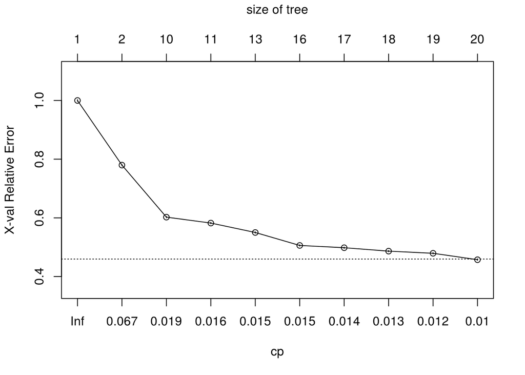

## Tree

### Summary of the tree

```
##
## Model formula:
## attentionName ~ boxHeight + boxRotation + boxArea + boxWidth +
##     widthHeightRatio + boxYcoordRel
##
## Fitted party:
## [1] root
## |   [2] boxYcoordRel >= 0.54778
## |   |   [3] widthHeightRatio >= 0.35135
## |   |   |   [4] boxHeight < 16.00745: ipad (n = 16629, err = 1.4%)
## |   |   |   [5] boxHeight >= 16.00745: tv (n = 3835, err = 36.8%)
## |   |   [6] widthHeightRatio < 0.35135
## |   |   |   [7] widthHeightRatio < 0.31238: ipad (n = 3953, err = 6.3%)
## |   |   |   [8] widthHeightRatio >= 0.31238
## |   |   |   |   [9] boxHeight >= 40.9099: ipad (n = 4474, err = 25.0%)
## |   |   |   |   [10] boxHeight < 40.9099
## |   |   |   |   |   [11] boxYcoordRel >= 0.61653
## |   |   |   |   |   |   [12] boxYcoordRel < 0.71029: ipad (n = 5348, err = 32.9%)
## |   |   |   |   |   |   [13] boxYcoordRel >= 0.71029: tv (n = 961, err = 5.8%)
## |   |   |   |   |   [14] boxYcoordRel < 0.61653: tv (n = 11460, err = 30.2%)
## |   [15] boxYcoordRel < 0.54778
## |   |   [16] boxWidth < 35.16975
## |   |   |   [17] boxYcoordRel >= 0.41326: ipad (n = 3576, err = 8.3%)
## |   |   |   [18] boxYcoordRel < 0.41326
## |   |   |   |   [19] boxHeight < 19.00845
## |   |   |   |   |   [20] boxYcoordRel >= 0.11489
## |   |   |   |   |   |   [21] boxRotation >= -1.25045: ipad (n = 8462, err = 21.0%)
## |   |   |   |   |   |   [22] boxRotation < -1.25045
## |   |   |   |   |   |   |   [23] boxYcoordRel >= 0.26961: ipad (n = 7462, err = 33.6%)
## |   |   |   |   |   |   |   [24] boxYcoordRel < 0.26961
## |   |   |   |   |   |   |   |   [25] boxHeight < 12.36005: ipad (n = 1973, err = 16.8%)
## |   |   |   |   |   |   |   |   [26] boxHeight >= 12.36005: tv (n = 9895, err = 24.7%)
## |   |   |   |   |   [27] boxYcoordRel < 0.11489: tv (n = 6240, err = 8.3%)
## |   |   |   |   [28] boxHeight >= 19.00845: tv (n = 10830, err = 12.2%)
## |   |   [29] boxWidth >= 35.16975
## |   |   |   [30] boxHeight < 13.15735
## |   |   |   |   [31] boxYcoordRel >= 0.11538
## |   |   |   |   |   [32] widthHeightRatio < 0.34755: ipad (n = 10502, err = 28.2%)
## |   |   |   |   |   [33] widthHeightRatio >= 0.34755: tv (n = 1238, err = 4.8%)
## |   |   |   |   [34] boxYcoordRel < 0.11538: tv (n = 13081, err = 16.5%)
## |   |   |   [35] boxHeight >= 13.15735
## |   |   |   |   [36] widthHeightRatio >= 0.41936
## |   |   |   |   |   [37] boxYcoordRel >= 0.40369: ipad (n = 4122, err = 21.0%)
## |   |   |   |   |   [38] boxYcoordRel < 0.40369: tv (n = 13734, err = 14.7%)
## |   |   |   |   [39] widthHeightRatio < 0.41936: tv (n = 105579, err = 9.9%)
##
## Number of inner nodes:    19
## Number of terminal nodes: 20
```

### Visualisation of the tree

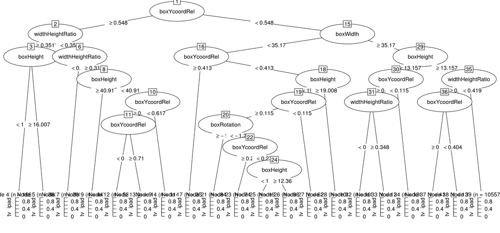

## Error metrics analysis

Confusion matrix from the application of the tree predictor to the testing set of data.

```
##       predclass
##         ipad    tv
##   ipad 26818 11896
##   tv    6023 75471
```

### Error metrics based on prediction of attention to the iPad.

True negatives: 75471

False negatives: 6023

True positives: 26818

False positives: 11896

**Error-rate**: the proportion of the incorrectly classified examples -> (fp+fn)/(tp+tn+fp+tn)

**14.9066618**

**Accuracy**: the proportion of the correctly classified examples -> (tp+tn)/(tp+tn+fp+tn)

**85.0933382**

As the number of instances of the response variable is not balanced (there are many more instances with false than true) the accuracy is not a good indicator. Other cost sensitive measures are reported here. -> cost sensitive measures

**Precision**: positive predicted value (PPV) -> tp/(tp+fp), a measure of exactness

**69.2720979**

**Recall/Sensitivity**: true positive recognition rate -> tp/(tp+fn), a measure of completeness

**81.66012**

**Specificity**: true negative recognition rate -> tn/(tn+fp)

**86.3838749**

**F measure**: the balance between precision and recall -> 2*tp/(2*tp+fp+fn)

**74.9577248**

### Error metrics based on prediction of attention to the TV.

True negatives: 26818

False negatives: 11896

True positives: 75471

False positives: 6023

**Error-rate**: the proportion of the incorrectly classified examples -> (fp+fn)/(tp+tn+fp+tn)

**14.9066618**

**Accuracy**: the proportion of the correctly classified examples -> (tp+tn)/(tp+tn+fp+tn)

**85.0933382**

**Precision**: positive predicted value (PPV) -> tp/(tp+fp), a measure of exactness

**92.6092718**

**Recall/Sensitivity**: true positive recognition rate -> tp/(tp+fn), a measure of completeness

**86.3838749**

**Specificity**: true negative recognition rate -> tn/(tn+fp)

**81.66012**

**F measure**: the balance between precision and recall -> 2*tp/(2*tp+fp+fn)

**89.3883135**